# Analysis of Variance

Dr. Josh Jacobson

2 February 2026

*These lecture notes were originally developed by Dr. Kris Pruitt.*

The purpose of this lesson is to conduct hypothesis tests for the parameters of a multiple linear regression model. Specifically, we explore computational and mathematical methods for the analysis of variance (ANOVA).

# Types of Variance

In previous lessons, we constructed confidence intervals and completed hypothesis tests on the sole slope parameter of a simple linear regression model. For this lesson, we extend those concepts to the multiple slope parameters of the model shown below.

$$y=\beta_0 + \beta_1x_1 + \beta_2x_2 + ... + \beta_px_p + \epsilon$$

We are typically uninterested in making inferences about the intercept parameter, since it often has no real-world interpretation. Instead, we focus on the $p$ slope parameters, since they indicate the change in the response for a one unit increase in the associated predictor (all other variables held constant). However, it is no longer as simple as conducting a hypothesis test on a single slope. We now have many slopes. If we were to conduct all of the hypothesis tests individually, we would be at a high risk of suffering at least one false positive. Instead, we apply a method known as the analysis of variance (ANOVA) to determine if *any* of the predictor variables are significant.

An ANOVA hypothesis test measures two types of variance (hence analysis of “variance”). The first type is directly related to the residual standard error (RSE). We commonly refer to this as the **mean squared error (MSE)**.

$$\begin{aligned}
\text{MSE} &= \text{RSE}^2 \\
&= \frac{\text{RSS}}{n-1-p}
\end{aligned}$$

When computing RSE, we employ the square-root in order to obtain the same units as the response variable. With MSE, we simply leave the measure of error in squared units. Thus, just as RSE is an estimate of the true error standard deviation ($\sigma$), MSE is an estimate of the true error variance ($\sigma^2$). In general, a smaller MSE indicates a model that better fits the data.

The second type of variance in ANOVA compares the performance of the fitted model to the null model. Many texts refer to this as the **mean squared error between groups (MSG)**. In this context, the number of “groups” is equivalent to the number of predictors $p$.

$$\text{MSG} = \frac{\text{TSS}-\text{RSS}}{p}$$

Recall that TSS is the total squared error associated with the model that employs *zero* predictors (i.e., only the mean response). By contrast, RSS is the total squared error for the model that uses $p$ predictors. If the model with $p$ predictors reduces the error, then we would expect the difference (TSS-RSS) in the numerator to be relatively large. Thus, a large MSG indicates a model that outperforms the null model.

When conducting an ANOVA test, we compute the ratio of these two types of variance. The resulting statistic follows an **F distribution**.

$$F = \frac{\text{MSG}}{\text{MSE}}$$

A model with $p$ predictors that fits the data well results in a large MSG and a small MSE. Consequently, the $F$-statistic for such a model is relatively large. A model that does *not* improve upon the null model results in an $F$-statistic value near 1. Below, we demonstrate ANOVA computationally and mathematically using a numerical example.

# Computational Method

In order to demonstrate an ANOVA for the slope parameters of a multiple linear regression model we will use a sample of National Basketball Association (NBA) games from the 2017-2019 seasons. Specifically, we will fit a model for margin of victory (`MOV`) as a function of free-throw percentage (`X1PP`), two-point percentage (`X2PP`), and three-point percentage (`X3PP`). Import and wrangle the data below.

```r
# import data
nba <- read_csv("basketball.csv") %>%
  select(MOV, X1PP, X2PP, X3PP) %>%
  na.omit()
```

We are interested in the model below, where $y$ is the margin of victory and $x_1,x_2,x_3$ are the three shooting percentages.

$$y=\beta_0 + \beta_1x_1 + \beta_2x_2 + \beta_3x_3 + \epsilon$$

The hypotheses for an ANOVA test are as follows:

$$\begin{aligned}
H_0:& \; \beta_1=\beta_2=\beta_3=0 \\
H_A:& \; \text{At least one} \; \beta_j \neq 0
\end{aligned}$$

Suppose we choose a significance level of $\alpha=0.01$. Thus, we accept a 1% chance of finding the model useful when in fact it is not. Next, we must compute the $F$-statistic described in the previous section. First we fit the multiple linear regression model. Then we compute RSS for the fitted model and TSS for the null model. Finally, we calculate the $F$-statistic as the ratio of MSG to MSE.

```r
# fit multiple regression model
# NOTE: the "." in the formula below tells R to use
# all remaining columns in the data as predictors
model <- lm(MOV ~ ., data = nba)

# compute TSS and RSS
nba_mod <- nba %>%
  mutate(
    MOV_bar = mean(nba$MOV),
    MOV_hat = predict(model, newdata = nba)
  ) %>%
  summarize(
    TSS = sum((MOV - MOV_bar)^2),
    RSS = sum((MOV - MOV_hat)^2)
  )

# calculate F-statistic
f_stat <- as.numeric(((nba_mod$TSS - nba_mod$RSS) / 3) / (nba_mod$RSS / 995))

f_stat
```

```
## [1] 163.0233
```

The test statistic resulting from the data is about 163. However, it is difficult to interpret the meaning of this value without a null distribution for comparison. The null hypothesis suggests *none* of the predictors are associated with the response. We can simulate this scenario by randomly shuffling the margin of victory values. By assigning a random margin of victory to each game, we break any potential correlations with the predictors. For example:

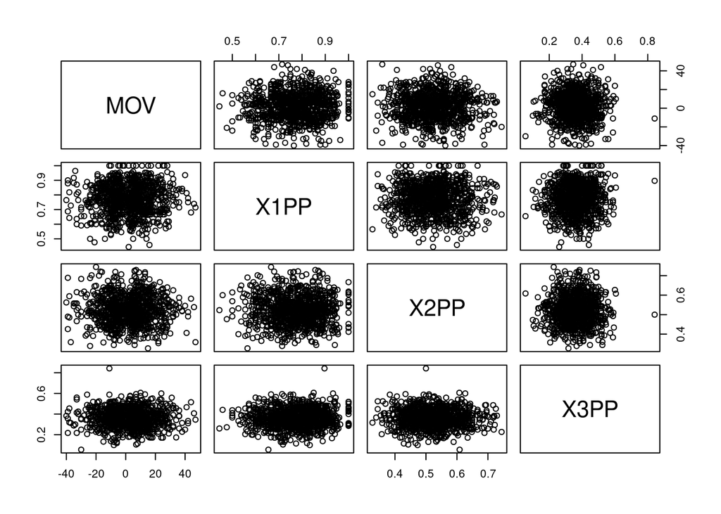

```r
nba_null <- nba %>%
  mutate(
    MOV = sample(MOV, size = 999, replace = FALSE)
  )

pairs(nba_null)
```

The code below shuffles the response values 1,000 times and computes the $F$-statistic for each iteration.

```r
# initiate empty vector
results <- data.frame(fstat = rep(NA, 1000))

# repeat randomization process 1000 times and save results
for (i in 1:1000) {
  set.seed(i)
  nba_null <- nba %>%
    mutate(
      MOV = sample(MOV, size = 999, replace = FALSE)
    )

  model_null <- lm(MOV ~ ., data = nba_null)

  nba_pred <- nba_null %>%
    mutate(
      MOV_bar = mean(nba_null$MOV),
      MOV_hat = predict(model_null, newdata = nba_null)
    ) %>%
    summarize(
      TSS = sum((MOV - MOV_bar)^2),
      RSS = sum((MOV - MOV_hat)^2)
    )

  results$fstat[i] <- as.numeric(
      ((nba_pred$TSS - nba_pred$RSS) / 3) / (nba_pred$RSS / 995)
    )
}
```

The results of our randomization process provide 1,000 test statistics aligned with the null hypothesis that none of the predictors are correlated with the response. These values represent the null distribution.

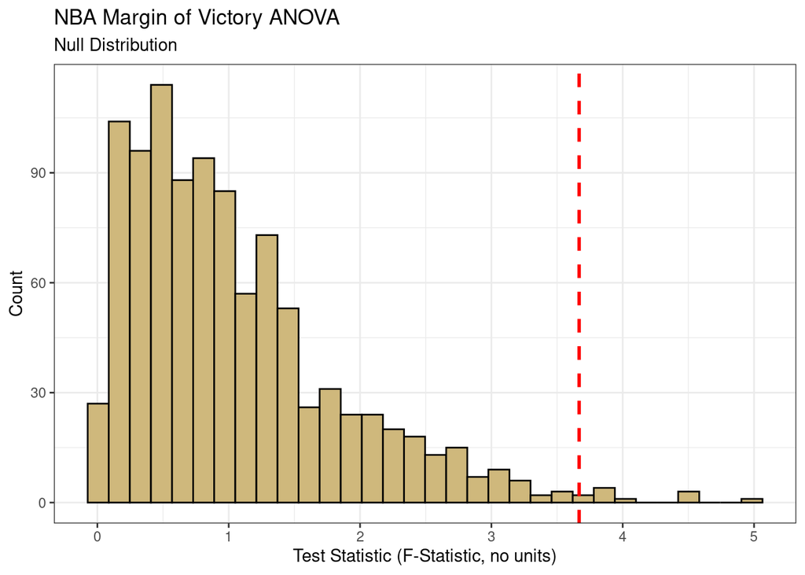

```r
# plot null distribution
ggplot(data = results, aes(x = fstat)) +
  geom_histogram(color = "black", fill = "#CFB87C", bins = 32) +
  geom_vline(
    xintercept = quantile(results$fstat, probs = 0.99),
    color = "red", linewidth = 1, linetype = "dashed"
  ) +
  labs(
    title = "NBA Margin of Victory ANOVA",
    subtitle = "Null Distribution",
    x = "Test Statistic (F-Statistic, no units)",
    y = "Count"
  ) +
  theme_bw()
```

The null distribution for the ANOVA is skewed to the right, with most of the values near 1. However, it would not be extraordinary to see values as large as 2 or 3. Based on our significance level of $\alpha=0.01$, values beyond about 3.67 would be considered too rare to continue believing the null hypothesis. Our observed value was 163! Thus, our test statistic is well beyond the rejection threshold. We reject the null hypothesis in favor of the alternate. We have sufficient evidence to suggest at least one of the predictors is associated with the response.

# Mathematical Method

Rather than constructing a randomized null distribution, we could take advantage of mathematical theory which assumes the $F$-distribution. The technical conditions required for this assumption are discussed in detail in future lessons. The $F$-distribution has two metrics for degrees of freedom, which are directly connected to the numerator and denominator of the $F$-statistic formula. The numerator degrees of freedom are equal to $p$ and the denominator degrees of freedom are $n-1-p$.

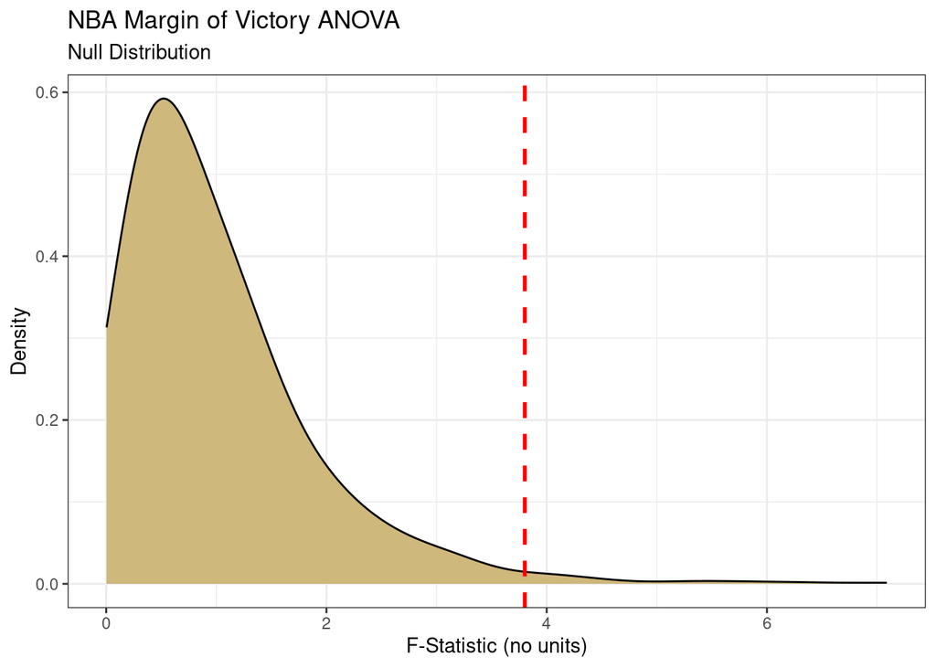

```r
# simulate F-distribution
set.seed(303)
fdist <- data.frame(fstat = rf(n = 1000, df1 = 3, df2 = 995))

# plot null distribution
ggplot(data = fdist, aes(x = fstat)) +
  geom_density(color = "black", fill = "#CFB87C", adjust = 2) +
  geom_vline(
    xintercept = qf(p = 0.01, df1 = 3, df2 = 995, lower.tail = FALSE),
    color = "red", linewidth = 1, linetype = "dashed"
  ) +
  labs(
    title = "NBA Margin of Victory ANOVA",
    subtitle = "Null Distribution",
    x = "F-Statistic (no units)",
    y = "Density"
  ) +
  theme_bw()
```

When we compare a test statistic of $F=163$ to this null distribution we obtain a p-value that is effectively zero. Thus, we reject the null hypothesis of the ANOVA. There is sufficient statistical evidence to suggest that *at least one* of the predictor variables has a non-zero coefficient. In other words, at least one of the shooting percentages is a useful predictor of margin of victory. In order to determine which one(s), we must refer to the individual hypothesis tests on each parameter.

Let’s review the summary output for the model we originally fit.

```r
# display model output
summary(model)
```

```
##
## Call:
## lm(formula = MOV ~ ., data = nba)
##
## Residuals:
##     Min      1Q  Median      3Q     Max
## -48.663  -8.243   0.188   8.116  33.312
##
## Coefficients:
##             Estimate Std. Error t value Pr(>|t|)
## (Intercept)  -69.491      4.212 -16.499  < 2e-16 ***
## X1PP          10.168      3.713   2.739  0.00628 **
## X2PP          75.845      5.122  14.808  < 2e-16 ***
## X3PP          66.975      4.145  16.156  < 2e-16 ***
## ---
## Signif. codes:  0 '***' 0.001 '**' 0.01 '*' 0.05 '.' 0.1 ' ' 1
##
## Residual standard error: 11.79 on 995 degrees of freedom
## Multiple R-squared:  0.3295, Adjusted R-squared:  0.3275
## F-statistic:   163 on 3 and 995 DF,  p-value: < 2.2e-16
```

Notice the last line of output includes an $F$-statistic. The value of 163 aligns with what we computed previously and the p-value of near-zero causes us to reject the null hypothesis. This p-value assumes the $F$-distribution and thus relies on mathematical theory.

# Individual Parameters

Within the `Coefficients` table we have test statistics (`t value`) and p-values (`Pr(>|t|)`) for the three slope parameters. For each parameter $\beta_j$, the hypotheses are:

$$\begin{aligned}
H_0:& \; \beta_j=0 \\
H_A:& \; \beta_j \neq 0
\end{aligned}$$

While we use an $F$-distribution for the ANOVA test (all parameters), we use a t-distribution for the individual parameter tests. For example, the test statistic for the free-throw percentage coefficient is $t=2.739$. We compare this to a t-distribution with $n-1-p$ degrees of freedom, aligned with the null hypothesis of zero and significance level of $\alpha=0.01$.

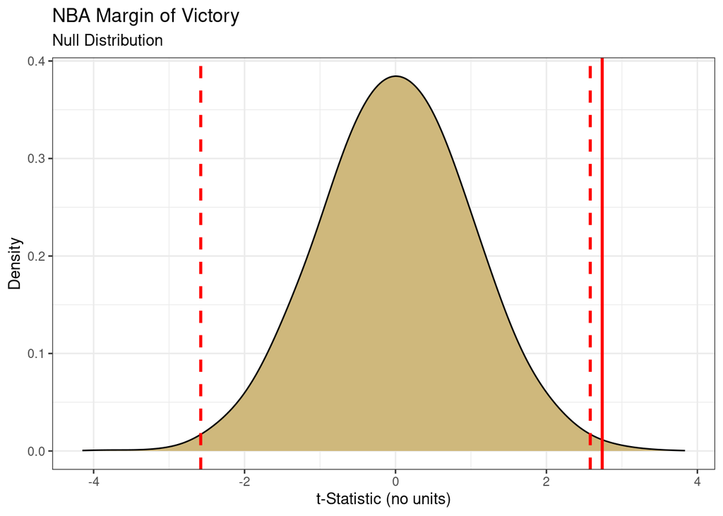

```r
# simulate t-distribution
set.seed(303)
tdist <- data.frame(tstat = rt(n = 10000, df = 995))

# plot null distribution
ggplot(data = tdist, aes(x = tstat)) +
  geom_density(color = "black", fill = "#CFB87C", adjust = 2) +
  geom_vline(
    xintercept = qt(p = 0.005, df = 995, lower.tail = TRUE),
    color = "red", linewidth = 1, linetype = "dashed"
  ) +
  geom_vline(
    xintercept = qt(p = 0.005, df = 995, lower.tail = FALSE),
    color = "red", linewidth = 1, linetype = "dashed"
  ) +
  geom_vline(xintercept = 2.739, color = "red", linewidth = 1) +
  labs(
    title = "NBA Margin of Victory",
    subtitle = "Null Distribution",
    x = "t-Statistic (no units)",
    y = "Density"
  ) +
  theme_bw()
```

Because the test statistic is (barely) beyond the significance threshold, we reject the null hypothesis. We can also compute the p-value and compare it to the significance level.

```r
# compute p-value
2 * pt(q = 2.739, df = 995, lower.tail = FALSE)
```

```
## [1] 0.006272762
```

This is the same p-value we observe in the summary output from the model and it is less than $\alpha=0.01$. Thus, we find sufficient evidence that $\beta_1\neq0$. However, when interpreting this result, we must be careful to reference the presence of the other predictors. In our case, we have sufficient statistical evidence to suggest free-throw percentage is associated with margin of victory **in a model that includes two-point and three-point shooting percentages**. Said another way, free-throw percentage is a valuable addition to the model even though we already have two-point and three-point percentages. Another common way to phrase this is that after controlling for two-point and three-point percentages, free-throw percentage is still a significant predictor for the margin of victory. The small p-values for all three explanatory variables tell us that each is valuable, even given the presence of the others.